# WK3 Running business intelligence using data Connect the dots

[interactive chart not shown]

Editor's Choice

1 May 2020

Running business intelligence using data: Connect the

dots

information-age.com

/running-business-intelligence-using-data-connect-dots-123489296

Lyndsay Wise, director of market intelligence at Information Builders, discusses moving

from collecting data to running business intelligence

Connect the dots, don't just collect them.

At our user summit last summer, one of our customers ended her keynote with the words,

“Are we connecting the dots, or just collecting them?” Over the past two decades as a data

industry analyst, I have never heard a better summary of the enterprise data challenge of

running business intelligence.

Overcoming challenges

Twenty years on, I see that many of the data challenges remain the same: unless

organisations start with effective data management, they will struggle to scale and they will

hamper their digital transformation as a result. At the same time, organisations have more

mature data infrastructures and many of the challenges involve stitching disparate data

sources together and creating an overall data value chain. This is actually quite complex as

organisations also need to consider security, privacy, regulatory requirements, and

governance.

By

[figure not shown]

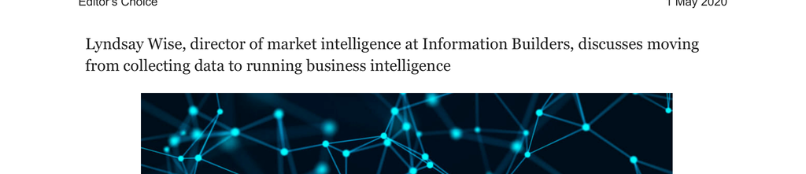

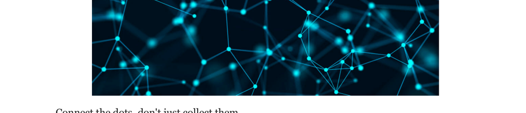

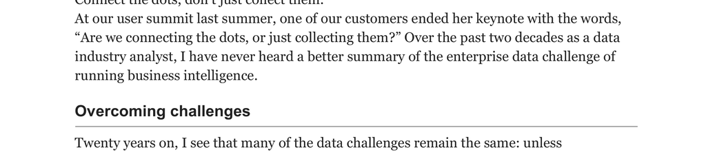

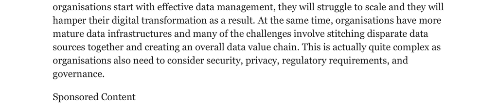

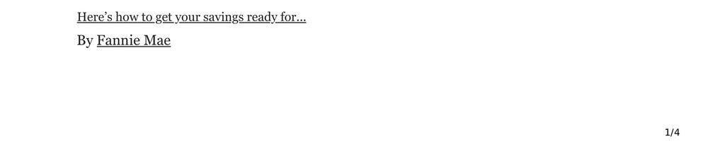

/

One of the key challenges is to address the complexities that

exist for data assets across the organisation. Organisations

look to data integration and data quality, but don’t always

take an iterative approach to design and maintenance. The

reality is that the only way to solve data challenges is to

make sure that iterative processes are in place to support

the organisational focus on continuous improvement.

Using data to improve customer experience

The overall repeatable success I have seen from organisations is when they use their

technology as an asset and not simply as a tool. In essence, this means looking at technology

and data as a way to drive success. Organisations that actually want to differentiate with

their customer experience need to understand their customers. This means analysing

historical information, demographics, products/services, customer satisfaction, and the list

goes on. This can be complex, but if organisations look at the data they need and how

stakeholders need to interact with information assets to get that view and understand the

customer story, they can succeed. Organisations that understand the concrete value of data

about customers, products, revenue, and how leveraging it relates to business, are more

likely to plan with outcomes in mind.

How to achieve ROI from data with asset management software

in oil and gas

Dr Neil Arthur

, technical director APM, Digital Products at Lloyd’

s

Register

, looks at how much ROI oil and gas companies are getting from

their investments in asset management software. Read here

Moving from collecting data to business intelligence

The better an organisation’s visibility into their data and the easier access they have, the

better able they are to make good business decisions. In my early career, seeing

organisations cut costs, increase profits, or lower customer churn was the proof point I

needed to shift my focus from business process re-engineering (BPR) to business

intelligence (BI) and analytics, as merging both skillsets was a great way to work with

organisations and support them through their data journeys.

In the not-for profit sector, business intelligence data and analytics are really important for

showing donors how their funds are being used, so that they continue to invest in causes

that they support. As an example, the largest privately-funded not-for-profit organisation in

the world,

United Way

, ensures good governance by conducting regular studies to collect

data on donations and outcomes.

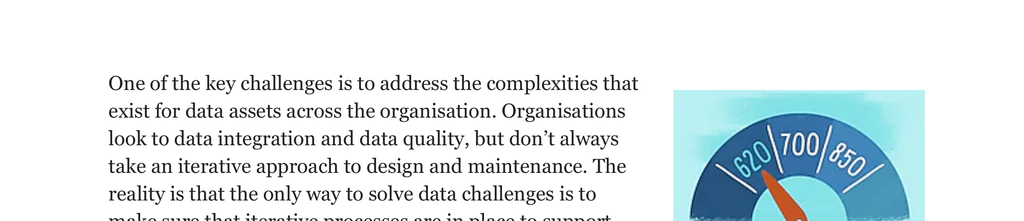

[figure not shown]

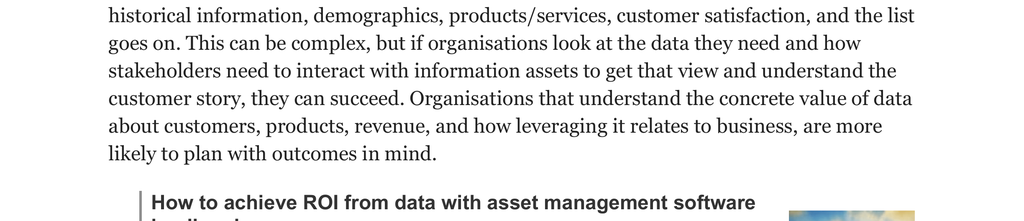

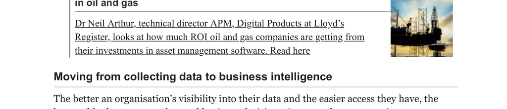

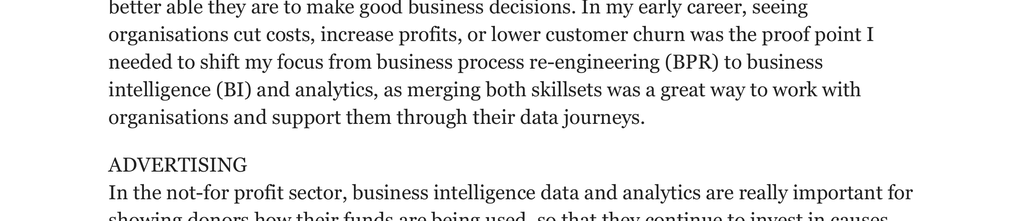

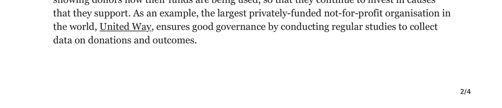

/

United Way realised that the entire staff would be more likely to recognise patterns,

dependencies and anomalies in data, if it were presented visually through dashboards, maps

and charts. However, data scientists are a scarce and costly resource, so United Way looked

for a way to share the findings from its impact studies, so that employees worldwide could

learn best practice from their peers and identify opportunities for improvement.

The PerformanceLink portal makes data easier to understand: helping staff to use it to meet

the urgent needs of beneficiaries. Customised scorecards and topic tabs reveal performance

by population grouping and allow United Way employees to more easily track the

effectiveness of charitable activities. Employees can also use the portal to create their own

dashboards and reports. Data can be visualised in scatter plots, with colour-coded quintile

scores revealing performance by population groupings. The portal automatically customises

data based on the user’s security clearance, location, interests and needs.

The self-service data analytics portal takes the information from United Ways’ national

research studies and displays performance, demographic, and socioeconomic information

on digital maps, charts, graphs and reports.

Should organisations be deploying analytics on mainframes?

Digital maps depict where United Way is operating within areas affected

by natural disasters, or ongoing deprivation, and this allows employees to

map ‘need indicators’ relative to these geographies. The powerful analytics and clarity of

data visualisations have helped United Way to optimise the distribution of financial and

human resources to support those most in need.

The PeformanceLink portal is now accessed by more than 13,000 authorised users to see

the results of the national research studies. Dashboards allow them to drill down from an

entire geographic region to an individual United Way affiliate. They can also use location

analytics to depict data geographically. These dynamic displays make it easy to see how each

affiliate is performing relative to its peers.

The rise of embedded analytics

I see more solution providers developing partnerships and options to leverage data

virtualisation, as well as more flexible information access points to ensure that

organisations have access to an experience that has a similar feel to accessing a single

platform. I think that this will help support organisations as they leverage embedded

analytics more broadly.

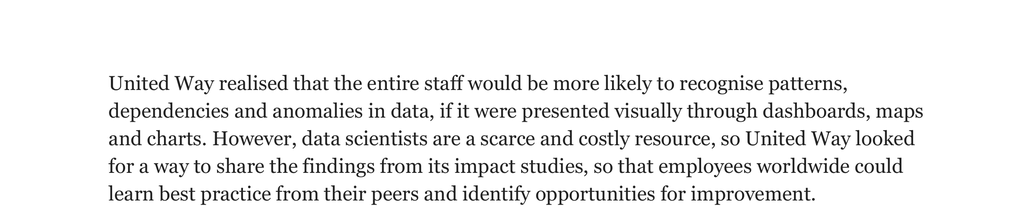

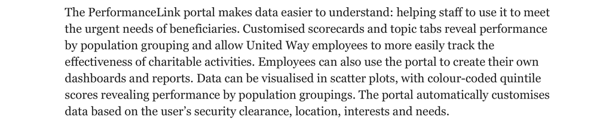

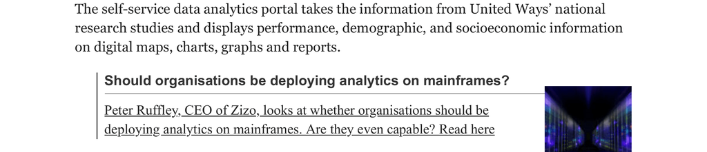

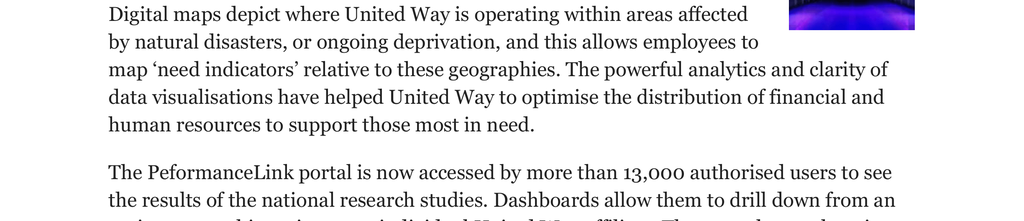

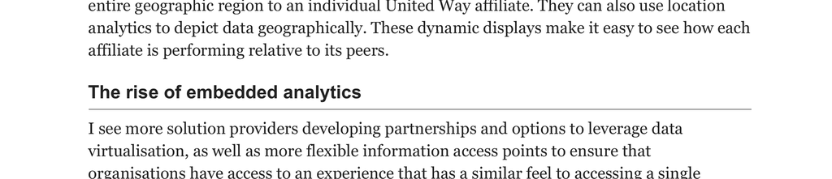

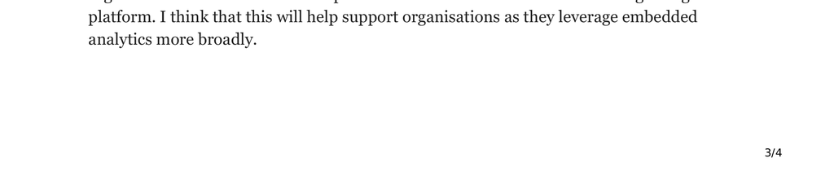

/

I believe that verticals such as healthcare, insurance, and government will require more data

sharing and open data ecosystems to deal with the after-effects of the COVID-19 pandemic.

This also applies to the way we look at data privacy and security of data across geographic

locations – for instance, within international travel. At the same time, the way business is

conducted and the competitive landscape may shift. Analysts are speaking a lot about the

need to adjust to a post-pandemic economy. Within organisations, the need for analytics to

drive business decisions will increase and become more important. Organisations that were

not data-driven will need to become so in order to remain competitive.

The future of data: how organisations can inspire data-driven

business transformation

Data supports all the technologies that are driving digital transformation.

here

There is an increasing focus on open ecosystems and broader access to data across

platforms by creating partnerships and API access with competitive and cooperative

technologies. I think as this data access increases, and organisations continue to look to

cloud-native applications and integration for support, embedded analytics will become

more commonplace and shift the way we consume data.

Written by

Lyndsay Wise

, director of market intelligence at

Information Builders

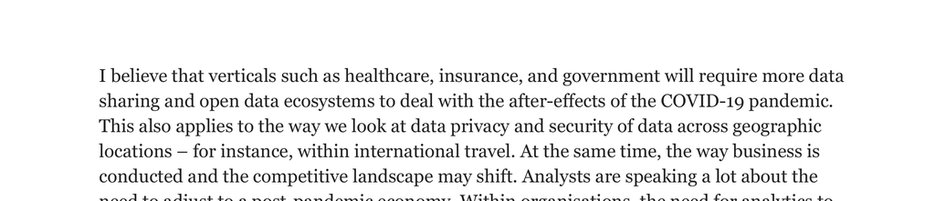

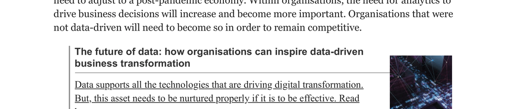

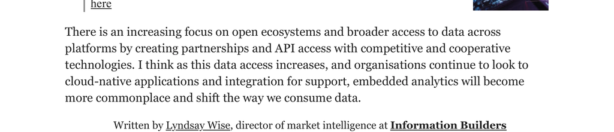

[figure not shown]

1

1x

2x

ST

[figure not shown]

Esc Close this cheat sheet

OthenA Open assignment

OthenC Open group or one-on-one chat

GthenH Go to Course Home

GthenG Go to My Scores

Ctrl + Shift + Alt + U Read next unread thread

Ctrl + Shift + Alt + C Open current conversation panel

Ctrl + Shift + Alt + A Open all conversations panel

Ctrl + Shift + Alt + R Open starred conversations panel

Ctrl + Shift + Alt + O Open table of contents panel

Ctrl + Shift + Alt + I Open notifications panel

Ctrl + Shift + Alt + B Open bookmarks panel

Ctrl + Shift + Alt + X Open notes panel

Ctrl + Shift + Alt + E Open read-aloud panel